# MSBR_FinalProject_Patricia_Chang

Patricia Chang

2023-10-05

## R Markdown

My goal is to see some interesting facts about U.S. fortune 1000 companies, and hopefully gain some insights for my job searching process.

```r
#Set up
library(dplyr)
```

```r
library(ggplot2)
fortune_data <- read.csv("/Users/daodao/Desktop/MSBA/WRANGLING/Final Project/fortune1000_2023.csv")
```

#1.I want to see what proportion of fortune CEO are female

```r
first_question <- (sum(fortune_data$FemaleCEO == "yes"))/1000
print(first_question)
```

```
## [1] 0.084
```

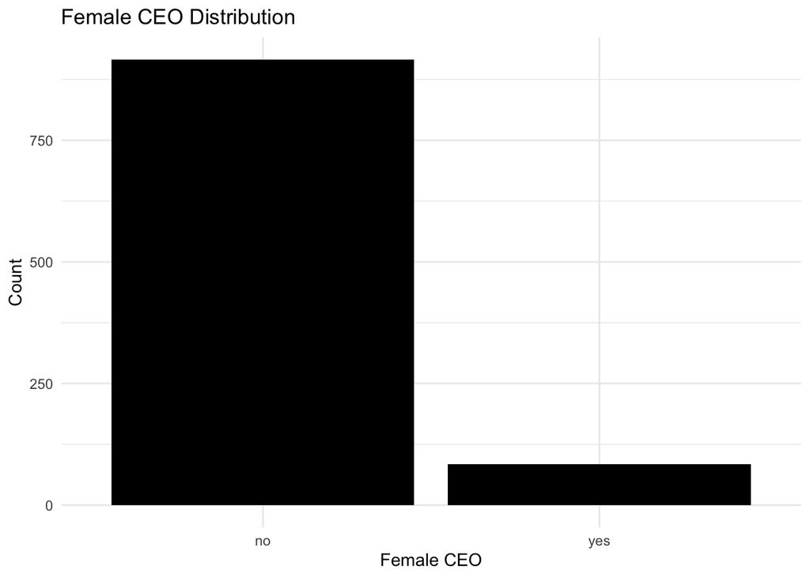

```r
ggplot(fortune_data, aes(x = FemaleCEO)) +
  geom_bar(fill = "black") +
  labs(
    title = "Female CEO Distribution",
    x = "Female CEO",
    y = "Count"
  ) +
  theme_minimal()
```

#And OMG, the proportion is less than 10%….

#2.I want to see who are the most outstanding new comers to the fortune 500

```r
second_question <- fortune_data %>%
  filter(Newcomer_to_the_Fortune500 == "yes", Profitable == "yes") %>%
  select(Change_in_Rank, Company, Sector, Profits_M)
print(second_question)
```

```
##    Change_in_Rank                              Company
## 1             260            Live Nation Entertainment
## 2              NA                               VMware
## 3             185                    Chesapeake Energy
## 4             116                     Alaska Air Group
## 5             137                Continental Resources
## 6             342                       Coterra Energy
## 7             107            Hilton Worldwide Holdings
## 8              80                             M&T Bank
## 9              78                               Airbnb
## 10             48                  Lululemon athletica
## 11            105                         Marathon Oil
## 12             55                Huntington Bancshares
## 13             35                       ABM Industries
## 14            334                                  EQT
```

[output cut: 33 more lines]

#Interesting, Lululemon and AirBnb are both rising up, and most of those new comers are making profit

#3.I want to see the fortune 1000 location distribution to see where their headquarters mostly clustered. To do that, I also merged another U.S. city dataset to get latitude and longitude info

```r
library(tidyverse)
```

```r
library(leaflet)
library(mapproj)
location_data <- read.csv("/Users/daodao/Desktop/uscities.csv")
fortune_data$city_state <- paste(fortune_data$HeadquartersCity, fortune_data$HeadquartersState, sep = " ")
location_data$city_state <- paste(location_data$city, location_data$state_id, sep = " ")
data_with_geo <- left_join(fortune_data, location_data, by = c("city_state" = "city_state"))
city_state_data1 <- data.frame(
  Company = data_with_geo$Company,
  City = data_with_geo$city_state,
  Latitude = data_with_geo$lat,
  Longitude = data_with_geo$lng
)
mymap1 <- leaflet() %>%
  setView(lng = -98.583333, lat = 39.833333, zoom = 4) %>%
  addTiles()
mymap1 <- mymap1 %>%
  addCircleMarkers(
    data = city_state_data1,
    lng = ~Longitude,
    lat = ~Latitude,
    radius = ~3,
    stroke = FALSE,
    fillOpacity = 0.1,
    popup = ~Company
  )
mymap1
```

[interactive chart not shown]

#According to my map, most fortune 1000 companies are located in the Eastern part of U.S.

#4.I want to see the fortune 1000 location distribution to see where the companies with most revenue are

```r
city_state_data2 <- data.frame(
  Company = data_with_geo$Company,
  Revenue = data_with_geo$Revenues_M,
  City = data_with_geo$city_state,
  Latitude = data_with_geo$lat,
  Longitude = data_with_geo$lng
)
mymap2 <- leaflet() %>%
  setView(lng = -98.583333, lat = 39.833333, zoom = 4) %>%
  addTiles()
mymap2 <- mymap2 %>%
  addCircleMarkers(
    data = city_state_data2,
    lng = ~Longitude,
    lat = ~Latitude,
    radius = ~Revenue/10000,
    stroke = FALSE,
    fillOpacity = 0.1,
    popup = ~Company
  )
mymap2
```

[interactive chart not shown]

#Companies like Walmart,Amazon and Apple really stand out with big circles

#5. I want to see the percentage distribution of fortune 1000 companies in different sectors

```r
library(dplyr)
sector_distribution <- fortune_data %>%
  group_by(Sector) %>%
  summarize(
    Count = n(),
    Percentage = Count / nrow(fortune_data) * 100
  ) %>%
  arrange(desc(Count))

sector_distribution
```

```
## # A tibble: 21 × 3
##    Sector                    Count Percentage
##    <chr>                     <int>      <dbl>
##  1 Financials                  161       16.1
##  2 Technology                  117       11.7
##  3 Energy                      115       11.5
##  4 Health Care                  80        8
##  5 Retailing                    72        7.2
##  6 Business Services            52        5.2
##  7 Industrials                  49        4.9
##  8 Materials                    48        4.8
##  9 Transportation               39        3.9
## 10 Food, Beverages & Tobacco    33        3.3
## # ℹ 11 more rows
```

#Top three are financials, technology and energy. Alright, not really exciting for me.

#6. I want to see what are the profitable companies in the household product, retailing and apparel sectors for job-searching consideration.

```r
target_companies <- fortune_data %>%
filter((Sector == "Household Products" | Sector == "Apparel" | Sector == "Retailing" ) & Profitable == "yes") %>%
select(Rank, Sector, Company, HeadquartersCity)
target_companies
```

```
##    Rank             Sector                     Company HeadquartersCity
## 1     1          Retailing                     Walmart      Bentonville
## 2    12          Retailing            Costco Wholesale         Issaquah
## 3    20          Retailing                  Home Depot          Atlanta
## 4    33          Retailing                      Target      Minneapolis
## 5    39          Retailing                      Lowe's      Mooresville
## 6    51 Household Products            Procter & Gamble       Cincinnati
## 7    87          Retailing                         TJX       Framingham
## 8    93            Apparel                        Nike        Beaverton
## 9    94          Retailing                    Best Buy        Richfield
## 10  108          Retailing              Dollar General   Goodlettsville
## 11  124          Retailing                      CarMax         Richmond
## 12  144          Retailing                 Dollar Tree       Chesapeake
## 13  145          Retailing               Lithia Motors          Medford
## 14  147          Retailing     Penske Automotive Group Bloomfield Hills
```

[output cut: 77 more lines]

#Thanks R studio, now I know what are the companies I’m going to apply next year